# act_report

## Report:

**Act Report: Insights from WeRateDogs Data Analysis**

**Introduction** WeRateDogs is a popular Twitter account known for its humorous and unconventional dog ratings. In this report, we will analyze the WeRateDogs Twitter data to gain insights into dog names, engagement level, and dog ratings. Through data wrangling and exploratory data analysis, we have uncovered interesting patterns and trends.

**Insight 1: The Top 10 Most Common Dog Names**  
After analyzing the dog names in the dataset, we found that the most common dog name is Charlie. This insight is visually represented in a bar chart, showcasing the top 10 most common dog names and their frequencies.

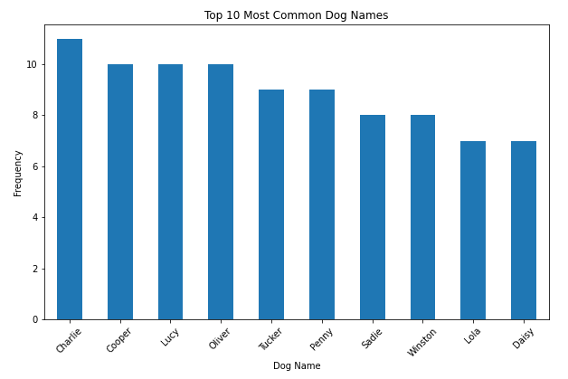

**Insight 2: Relationship between Favorited Tweets and Retweet Counts**  
By examining the relationship between favorite counts and retweet counts, we discovered a positive correlation. This insight is effectively communicated through a scatter plot, which displays the distribution of favorited tweets and retweet counts.

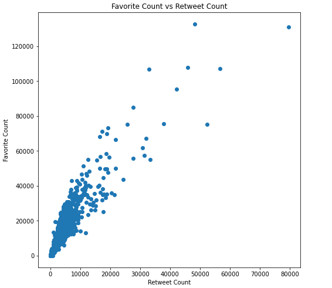

**Insight 3: Most Common Dog Rating**  
The analysis revealed that the most common dog rating is 12/10. This insight is conveyed through a pie chart, presenting the distribution of dog ratings and highlighting the percentage of each rating.

[figure not shown]

**Visualization: Engagement level of tweets over time**  
To analyze the engagement level of tweets, we plotted the number of retweets and favorites (likes) over time using a line chart. This visualization helps identify any patterns or trends in tweet engagement.

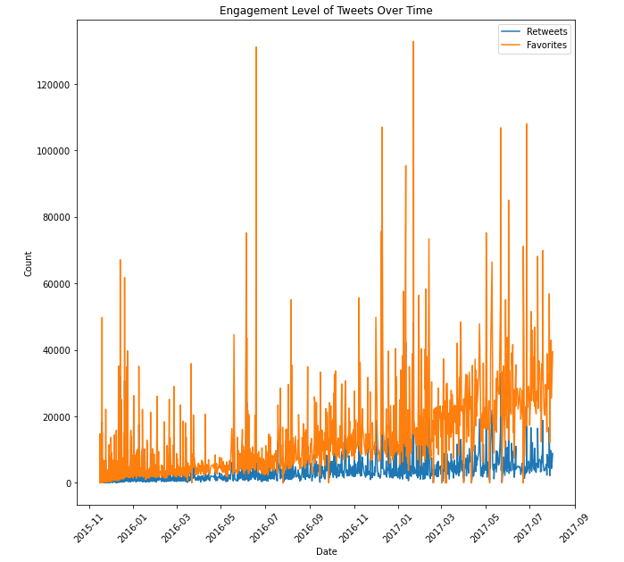